# Table of Contents

### Вывод:

Первые игры начали выпускать в 1980 году. Интересно наблюдать, как происходил рывок каждое десятилетие по количеству выпускаем игр. При этом с 2010 года началось падение количества выпускаемых игр и в 2016 году выходит в два раза меньше игр, чем в 2006 году.

При анализе по платфомам стало понятно, что у платформ есть срок службы около 7 лет. Старые платформы исчезают и появляются новые. В интересующем нас периоде актуальны две платформы PS4 и XOne. Так же интересны платформы WIIU, WII, DS.

У пользователей есть любимые жанры игр, это Action и Sports. Именно на эти жанры приходится больше всего продаж. Жанры Shooter и Role-Playing, так же интересны для продвижения игр и рекламных компаний.

## Портрет пользователя каждого региона

### Топ-5 платформ для регионов

```python
df_region = df.pivot_table(index=['platform'],
                           values= ['na_sales','eu_sales','jp_sales'],
                           aggfunc='sum')
df_region
```

| platform | eu_sales | jp_sales | na_sales |
| --- | --- | --- | --- |
| 2600 | 4.86 | 0.00 | 80.78 |
| 3do | 0.00 | 0.10 | 0.00 |
| 3ds | 61.27 | 100.62 | 82.65 |
| dc | 1.69 | 8.56 | 5.43 |
| ds | 188.41 | 175.02 | 380.31 |
| gb | 47.51 | 85.12 | 113.64 |
| gba | 74.59 | 46.56 | 184.12 |
| gc | 38.32 | 21.34 | 131.94 |
| gen | 5.52 | 2.67 | 19.27 |
| gg | 0.00 | 0.04 | 0.00 |
| n64 | 41.03 | 33.76 | 138.91 |
| nes | 21.15 | 98.65 | 125.94 |
| ng | 0.00 | 1.44 | 0.00 |
| pc | 140.34 | 0.17 | 93.34 |
| pcfx | 0.00 | 0.03 | 0.00 |
| ps | 212.39 | 139.78 | 334.72 |
| ps2 | 332.63 | 137.54 | 572.92 |
| ps3 | 327.20 | 79.41 | 390.13 |
| ps4 | 141.09 | 15.96 | 108.74 |
| psp | 65.62 | 75.88 | 107.27 |
| psv | 13.07 | 21.84 | 12.47 |
| sat | 0.54 | 32.26 | 0.72 |
| scd | 0.36 | 0.45 | 1.00 |
| snes | 19.04 | 116.55 | 61.23 |
| tg16 | 0.00 | 0.16 | 0.00 |
| wii | 258.32 | 68.28 | 486.87 |
| wiiu | 25.13 | 13.01 | 38.10 |
| ws | 0.00 | 1.42 | 0.00 |
| x360 | 268.32 | 12.30 | 595.74 |
| xb | 59.65 | 1.38 | 182.06 |
| xone | 51.59 | 0.34 | 93.12 |

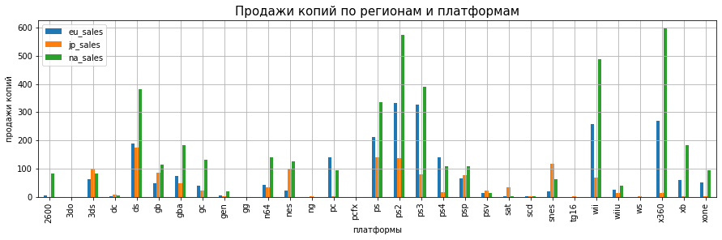

```python
df_region.pivot_table(index=['platform'],
                           values= ['na_sales','eu_sales','jp_sales'],
                           aggfunc='sum').plot(kind = 'bar', figsize = (15,4), grid=True, legend = True);
plt.title('Продажи копий по регионам и платформам',fontsize = 15);
plt.xlabel('платформы', fontsize = 10);
plt.ylabel('продажи копий', fontsize = 10);
plt.legend( fontsize = 10, loc=0);
```

Рассмотрим абсолютные продажи по регионам Северная Америка, Европа и Япония.

PS, PS2, PS3 знакомы Японии, а вот продажи X360 маленькие. То же самое мозно сказать про платформу WIIU.

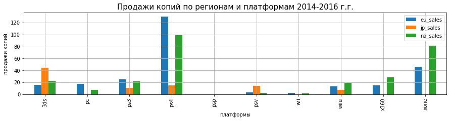

```python
df.query('year_of_release>2013').pivot_table(index=['platform'],
                           values= ['na_sales','eu_sales','jp_sales'],
                           aggfunc='sum').plot(kind = 'bar', figsize = (15,3), grid=True, legend = True);
plt.title('Продажи копий по регионам и платформам 2014-2016 г.г.',fontsize = 15);
plt.xlabel('платформы', fontsize = 10);
plt.ylabel('продажи копий', fontsize = 10);
plt.legend( fontsize = 10, loc=0);
```

Рассмотрим продажи в актуальном периоде. Видно, что осталось гораздо меньше платформ. Лидером является PS4, больше всего покупок на этой платформе делают в Европе.

Вторым лидером является платформа XOne, но по ней почти нет продаж в Японии.

При этом в Японии лидирует платформа 3DS.

### Доли продаж по регионам по платформам

```python
percent_platform = df.pivot_table(index=['platform'],
                           values= ['na_sales','eu_sales','jp_sales','sum_sales','name'],
                           aggfunc={'na_sales':'sum','eu_sales':'sum','jp_sales':'sum','sum_sales':'sum','name':'count'})

percent_platform['na_percent'] = round(percent_platform['na_sales']/percent_platform['sum_sales']*100,2)
percent_platform['eu_percent'] = round(percent_platform['eu_sales']/percent_platform['sum_sales']*100,2)
percent_platform['jp_percent'] = round(percent_platform['jp_sales']/percent_platform['sum_sales']*100,2)
percent_platform
```

| platform | eu_sales | jp_sales | na_sales | name | sum_sales | na_percent | eu_percent | jp_percent |
| --- | --- | --- | --- | --- | --- | --- | --- | --- |
| 2600 | 4.86 | 0.00 | 80.78 | 116 | 86.48 | 93.41 | 5.62 | 0.00 |
| 3do | 0.00 | 0.10 | 0.00 | 3 | 0.10 | 0.00 | 0.00 | 100.00 |
| 3ds | 61.27 | 100.62 | 82.65 | 512 | 257.81 | 32.06 | 23.77 | 39.03 |
| dc | 1.69 | 8.56 | 5.43 | 52 | 15.95 | 34.04 | 10.60 | 53.67 |
| ds | 188.41 | 175.02 | 380.31 | 2121 | 802.78 | 47.37 | 23.47 | 21.80 |
| gb | 47.51 | 85.12 | 113.64 | 97 | 254.43 | 44.66 | 18.67 | 33.46 |
| gba | 74.59 | 46.56 | 184.12 | 811 | 312.88 | 58.85 | 23.84 | 14.88 |
| gc | 38.32 | 21.34 | 131.94 | 542 | 196.73 | 67.07 | 19.48 | 10.85 |
| gen | 5.52 | 2.67 | 19.27 | 27 | 28.35 | 67.97 | 19.47 | 9.42 |
| gg | 0.00 | 0.04 | 0.00 | 1 | 0.04 | 0.00 | 0.00 | 100.00 |
| n64 | 41.03 | 33.76 | 138.91 | 316 | 218.01 | 63.72 | 18.82 | 15.49 |
| nes | 21.15 | 98.65 | 125.94 | 98 | 251.05 | 50.17 | 8.42 | 39.29 |
| ng | 0.00 | 1.44 | 0.00 | 12 | 1.44 | 0.00 | 0.00 | 100.00 |
| pc | 140.34 | 0.17 | 93.34 | 956 | 255.72 | 36.50 | 54.88 | 0.07 |
| pcfx | 0.00 | 0.03 | 0.00 | 1 | 0.03 | 0.00 | 0.00 | 100.00 |
| ps | 212.39 | 139.78 | 334.72 | 1190 | 727.58 | 46.00 | 29.19 | 19.21 |
| ps2 | 332.63 | 137.54 | 572.92 | 2127 | 1233.56 | 46.44 | 26.97 | 11.15 |
| ps3 | 327.20 | 79.41 | 390.13 | 1305 | 931.33 | 41.89 | 35.13 | 8.53 |
| ps4 | 141.09 | 15.96 | 108.74 | 392 | 314.14 | 34.62 | 44.91 | 5.08 |
| psp | 65.62 | 75.88 | 107.27 | 1193 | 289.53 | 37.05 | 22.66 | 26.21 |
| psv | 13.07 | 21.84 | 12.47 | 429 | 53.81 | 23.17 | 24.29 | 40.59 |
| sat | 0.54 | 32.26 | 0.72 | 173 | 33.59 | 2.14 | 1.61 | 96.04 |
| scd | 0.36 | 0.45 | 1.00 | 6 | 1.86 | 53.76 | 19.35 | 24.19 |
| snes | 19.04 | 116.55 | 61.23 | 239 | 200.04 | 30.61 | 9.52 | 58.26 |
| tg16 | 0.00 | 0.16 | 0.00 | 2 | 0.16 | 0.00 | 0.00 | 100.00 |
| wii | 258.32 | 68.28 | 486.87 | 1286 | 891.18 | 54.63 | 28.99 | 7.66 |
| wiiu | 25.13 | 13.01 | 38.10 | 147 | 82.19 | 46.36 | 30.58 | 15.83 |
| ws | 0.00 | 1.42 | 0.00 | 6 | 1.42 | 0.00 | 0.00 | 100.00 |
| x360 | 268.32 | 12.30 | 595.74 | 1232 | 961.24 | 61.98 | 27.91 | 1.28 |
| xb | 59.65 | 1.38 | 182.06 | 803 | 251.57 | 72.37 | 23.71 | 0.55 |
| xone | 51.59 | 0.34 | 93.12 | 247 | 159.32 | 58.45 | 32.38 | 0.21 |

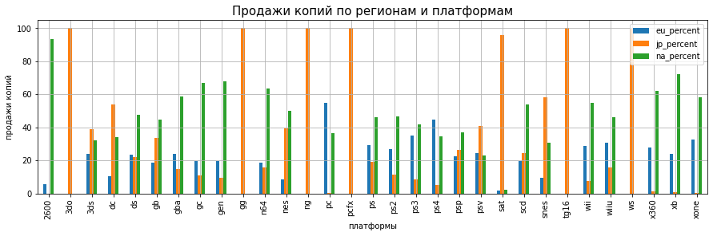

```python
percent_platform.pivot_table(index=['platform'],
                           values= ['na_percent','eu_percent','jp_percent'],
                           aggfunc='sum').plot(kind = 'bar', figsize = (15,4), grid=True, legend = True);
plt.title('Продажи копий по регионам и платформам',fontsize = 15);
plt.xlabel('платформы', fontsize = 10);
plt.ylabel('продажи копий', fontsize = 10);
plt.legend( fontsize = 10, loc=0);
```

Посмотрели доли продаж по регионам по платформам. В цифрах наглядно доли представлены, а на графике плохо читаемы. Так как есть, например, платформа NG, которая на графике дает 100% долю, что соответствует действительности по математике, но речь идет всего о 12 играх, которые были представлены только в Японии.

Считаю такой график не удобным для анализа.

Сделаем такую же аналитику для актуального периода:

```python
percent_platform_loc = df.query('year_of_release>2013').pivot_table(index=['platform'],
                           values= ['na_sales','eu_sales','jp_sales','sum_sales','name'],
                           aggfunc={'na_sales':'sum','eu_sales':'sum','jp_sales':'sum','sum_sales':'sum','name':'count'})

percent_platform_loc['na_percent'] = round(percent_platform['na_sales']/percent_platform['sum_sales']*100,2)
percent_platform_loc['eu_percent'] = round(percent_platform['eu_sales']/percent_platform['sum_sales']*100,2)
percent_platform_loc['jp_percent'] = round(percent_platform['jp_sales']/percent_platform['sum_sales']*100,2)
percent_platform_loc
```

| platform | eu_sales | jp_sales | na_sales | name | sum_sales | na_percent | eu_percent | jp_percent |
| --- | --- | --- | --- | --- | --- | --- | --- | --- |
| 3ds | 16.12 | 44.24 | 22.64 | 212 | 86.68 | 32.06 | 23.77 | 39.03 |
| pc | 17.97 | 0.00 | 7.23 | 151 | 27.05 | 36.50 | 54.88 | 0.07 |
| ps3 | 25.54 | 11.22 | 22.05 | 219 | 68.18 | 41.89 | 35.13 | 8.53 |
| ps4 | 130.04 | 15.02 | 98.61 | 376 | 288.15 | 34.62 | 44.91 | 5.08 |
| psp | 0.00 | 0.36 | 0.00 | 13 | 0.36 | 37.05 | 22.66 | 26.21 |
| psv | 3.53 | 14.54 | 2.52 | 295 | 22.40 | 23.17 | 24.29 | 40.59 |
| wii | 2.59 | 0.00 | 2.08 | 11 | 5.07 | 54.63 | 28.99 | 7.66 |
| wiiu | 13.15 | 7.31 | 19.36 | 73 | 42.98 | 46.36 | 30.58 | 15.83 |
| x360 | 15.49 | 0.08 | 28.30 | 111 | 48.22 | 61.98 | 27.91 | 1.28 |
| xone | 46.25 | 0.32 | 81.27 | 228 | 140.36 | 58.45 | 32.38 | 0.21 |

У нас всего 10 платформ за 2014-2016 года. Есть две "микро" платфомы с количеством игр 13 и 11 шт.

Посмотрим столбчатую диаграмму по этим данным:

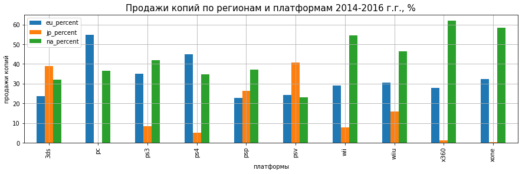

```python
percent_platform_loc.pivot_table(index=['platform'],
                           values= ['na_percent','eu_percent','jp_percent'],
                           aggfunc='sum').plot(kind = 'bar', figsize = (15,4), grid=True, legend = True);
plt.title('Продажи копий по регионам и платформам 2014-2016 г.г., %',fontsize = 15);
plt.xlabel('платформы', fontsize = 10);
plt.ylabel('продажи копий', fontsize = 10);
plt.legend( fontsize = 10, loc=0);
```

```python
percent_platform = df.query('year_of_release>2013').pivot_table(index=['platform'],
                           values= ['na_sales','eu_sales','jp_sales'],
                           aggfunc={'na_sales':'sum','eu_sales':'sum','jp_sales':'sum'})
percent_platform['eu_per'] = round((percent_platform['eu_sales'] / percent_platform['eu_sales'].sum()) * 100,2)
percent_platform['jp_per'] = round((percent_platform['jp_sales'] / percent_platform['jp_sales'].sum()) * 100,2)
percent_platform['na_per'] = round((percent_platform['na_sales'] / percent_platform['na_sales'].sum()) * 100,2)
percent_platform
```

| platform | eu_sales | jp_sales | na_sales | eu_per | jp_per | na_per |
| --- | --- | --- | --- | --- | --- | --- |
| 3ds | 16.12 | 44.24 | 22.64 | 5.96 | 47.52 | 7.97 |
| pc | 17.97 | 0.00 | 7.23 | 6.64 | 0.00 | 2.55 |
| ps3 | 25.54 | 11.22 | 22.05 | 9.44 | 12.05 | 7.76 |
| ps4 | 130.04 | 15.02 | 98.61 | 48.04 | 16.13 | 34.71 |
| psp | 0.00 | 0.36 | 0.00 | 0.00 | 0.39 | 0.00 |
| psv | 3.53 | 14.54 | 2.52 | 1.30 | 15.62 | 0.89 |
| wii | 2.59 | 0.00 | 2.08 | 0.96 | 0.00 | 0.73 |
| wiiu | 13.15 | 7.31 | 19.36 | 4.86 | 7.85 | 6.82 |
| x360 | 15.49 | 0.08 | 28.30 | 5.72 | 0.09 | 9.96 |
| xone | 46.25 | 0.32 | 81.27 | 17.09 | 0.34 | 28.61 |

```
platform
ps4       48.04
xone      17.09
ps3        9.44
pc         6.64
3ds        5.96
другие    12.84
Name: eu_per, dtype: float64
```

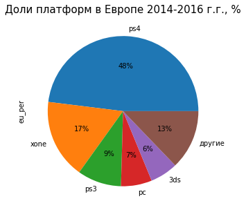

```python
top_platform_eu = percent_platform['eu_per'].sort_values(ascending=False).head(10)
top_platform_eu['другие'] = top_platform_eu[5:].sum()
top_platform_eu = top_platform_eu[top_platform_eu > 5.72]

print(top_platform_eu)
top_platform_eu.plot.pie(figsize=(8, 5), fontsize = 10, legend = False,autopct='%1.0f%%');
plt.title('Доли платформ в Европе 2014-2016 г.г., %',fontsize = 15);
```

```
platform
3ds       47.52
ps4       16.13
psv       15.62
ps3       12.05
wiiu       7.85
другие     0.82
Name: jp_per, dtype: float64
```

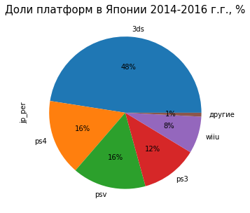

```python
top_platform_jp = percent_platform['jp_per'].sort_values(ascending=False).head(10)
top_platform_jp['другие'] = top_platform_jp[5:].sum()
top_platform_jp = top_platform_jp[top_platform_jp > 0.8]
print(top_platform_jp)
top_platform_jp.plot.pie(subplots=True,figsize=(8, 5), fontsize = 10, legend = False,autopct='%1.0f%%');
plt.title('Доли платформ в Японии 2014-2016 г.г., %',fontsize = 15);
```

```
platform
ps4       34.71
xone      28.61
x360       9.96
3ds        7.97
ps3        7.76
другие    10.99
Name: na_per, dtype: float64
```

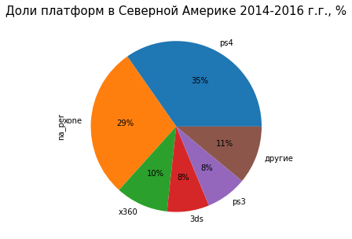

```python
top_platform_na = percent_platform['na_per'].sort_values(ascending=False).head(10)
top_platform_na['другие'] = top_platform_na[5:].sum()
top_platform_na = top_platform_na[top_platform_na > 7]
print(top_platform_na)
top_platform_na.plot.pie(subplots=True,figsize=(8, 5), fontsize = 10, legend = False,autopct='%1.0f%%');
plt.title('Доли платформ в Северной Америке 2014-2016 г.г., %',fontsize = 15);
```

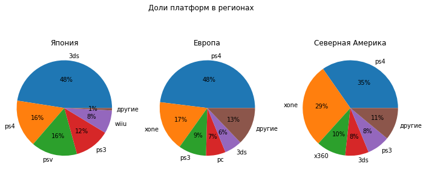

```python
fig, axs = plt.subplots(nrows=1 , ncols= 3,figsize=(12, 5))
fig. suptitle('Доли платформ в регионах')



axs[0].pie(top_platform_jp,autopct='%1.0f%%',labels = top_platform_jp.index);
axs[0].set_title('Япония')


axs[1].pie(top_platform_eu,autopct='%1.0f%%',labels = top_platform_eu.index);
axs[1].set_title('Европа')

axs[2].pie(top_platform_na,autopct='%1.0f%%',labels = top_platform_na.index);
axs[2].set_title('Северная Америка')
plt.show()
```

### Доли жанров по регионам

```python
df_genre_region = df.pivot_table(index=['genre'], values = ['na_sales','eu_sales','jp_sales'],
                                 aggfunc = 'sum')
df_genre_region['eu_per'] = round((df_genre_region['eu_sales'] / df_genre_region['eu_sales'].sum()) * 100,2)
df_genre_region['jp_per'] = round((df_genre_region['jp_sales'] / df_genre_region['jp_sales'].sum()) * 100,2)
df_genre_region['na_per'] = round((df_genre_region['na_sales'] / df_genre_region['na_sales'].sum()) * 100,2)

df_genre_region
```

| genre | eu_sales | jp_sales | na_sales | eu_per | jp_per | na_per |
| --- | --- | --- | --- | --- | --- | --- |
| Action | 510.99 | 160.14 | 863.17 | 21.29 | 12.41 | 19.88 |
| Adventure | 63.20 | 52.24 | 101.52 | 2.63 | 4.05 | 2.34 |
| Fighting | 99.00 | 87.28 | 220.51 | 4.13 | 6.76 | 5.08 |
| Misc | 210.60 | 107.02 | 399.57 | 8.78 | 8.29 | 9.20 |
| Platform | 199.39 | 130.71 | 444.44 | 8.31 | 10.13 | 10.24 |
| Puzzle | 49.78 | 56.68 | 121.13 | 2.07 | 4.39 | 2.79 |
| Racing | 234.49 | 56.63 | 356.86 | 9.77 | 4.39 | 8.22 |
| Role-Playing | 188.24 | 353.39 | 330.04 | 7.84 | 27.38 | 7.60 |
| Shooter | 314.52 | 38.68 | 584.83 | 13.11 | 3.00 | 13.47 |
| Simulation | 113.35 | 63.64 | 180.40 | 4.72 | 4.93 | 4.16 |
| Sports | 371.32 | 134.93 | 671.20 | 15.47 | 10.45 | 15.46 |
| Strategy | 44.76 | 49.30 | 67.75 | 1.87 | 3.82 | 1.56 |

```python
df_genre_region['jp_per'].sum()
```

```
99.99999999999999
```

Посчитали доли жанров по регионам, колонки eu_per, jp_per, na_per.

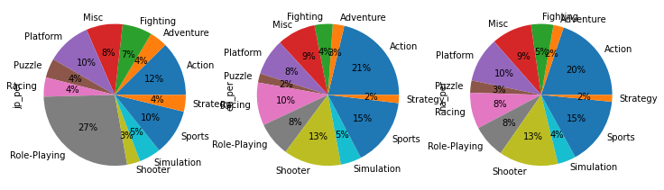

```python
df_genre_region_plt = df_genre_region[['jp_per','eu_per','na_per']]
df_genre_region_plt.plot.pie(subplots = True,figsize=(12, 5),stacked=True,legend = False,autopct='%1.0f%%');
```

Action жанр популярен Европе и Северной америке, вторым лидером будет Sport, третьим Shooter/

В Японии очень любят жанр Role-Playing.

Диаграмма выглядит не удобочитаемой. Выделим топ-5 жанров по регионам, остальные укажем как "другие", построим новую диаграмму.

```python
df_genre_region_jp = df_genre_region['jp_per'].sort_values(ascending = False)
df_genre_region_jp['другие'] = df_genre_region_jp[5:].sum()
df_genre_region_jp = df_genre_region_jp[df_genre_region_jp > 7]

df_genre_region_eu = df_genre_region['eu_per'].sort_values(ascending = False)
df_genre_region_eu['другие'] = df_genre_region_eu[5:].sum()
df_genre_region_eu = df_genre_region_eu[df_genre_region_eu > 8.4]

df_genre_region_na = df_genre_region['na_per'].sort_values(ascending = False)
df_genre_region_na['другие'] = df_genre_region_na[5:].sum()
df_genre_region_na = df_genre_region_na[df_genre_region_na > 9]

print(df_genre_region_jp)
print(df_genre_region_eu)
print(df_genre_region_na)
```

```
genre
Role-Playing    27.38
Action          12.41
Sports          10.45
Platform        10.13
Misc             8.29
другие          31.34
Name: jp_per, dtype: float64
genre
Action     21.29
Sports     15.47
Shooter    13.11
Racing      9.77
Misc        8.78
другие     31.57
Name: eu_per, dtype: float64
genre
Action      19.88
Sports      15.46
Shooter     13.47
Platform    10.24
Misc         9.20
другие      31.75
Name: na_per, dtype: float64
```

Пятерка лидеров в каждом регионе определена.

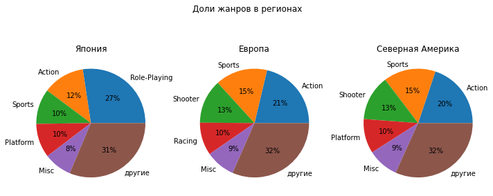

```python
fig, axs = plt.subplots(nrows=1 , ncols= 3,figsize=(12, 5))
fig. suptitle('Доли жанров в регионах')



axs[0].pie(df_genre_region_jp,autopct='%1.0f%%',labels = df_genre_region_jp.index);
axs[0].set_title('Япония')


axs[1].pie(df_genre_region_eu,autopct='%1.0f%%',labels = df_genre_region_eu.index);
axs[1].set_title('Европа')

axs[2].pie(df_genre_region_na,autopct='%1.0f%%',labels = df_genre_region_na.index);
axs[2].set_title('Северная Америка')
plt.show()
```

Анализ портрета пользователя показал, что европейцы и американцы похожи в своих предпочтениях жанров игр. На первом месте игры в жанре Action с долей 20%, затем Sports 15% и Shooter 13%. Есть различие в том что, американцы отдают предпочтение играм в жанре Platform 10%, а европейцы Racing с долей 10%.

Японцы отличаются от европейцев и американцев. В Японии пользователи предпочитают ролевые игры. Но в то же время, японцы так же как американцы любят игры в жанре Platform 10%.

### Рейтинг ESRB - влияние на продажи по регионам

```python
df_esrb_region = df.pivot_table(index='rating', values = ['na_sales','eu_sales','jp_sales'],
                                 aggfunc = 'sum')
df_esrb_region
```

| rating | eu_sales | jp_sales | na_sales |
| --- | --- | --- | --- |
| AO | 0.61 | 0.00 | 1.26 |
| E | 704.13 | 199.42 | 1276.80 |
| E10+ | 183.35 | 40.20 | 345.50 |
| EC | 0.11 | 0.00 | 1.53 |
| M | 480.00 | 63.58 | 742.89 |
| T | 421.79 | 150.70 | 747.60 |

Изменила тип данных в колонке rating на категорию, теперь не могу удалить строки...только обнулить могу.

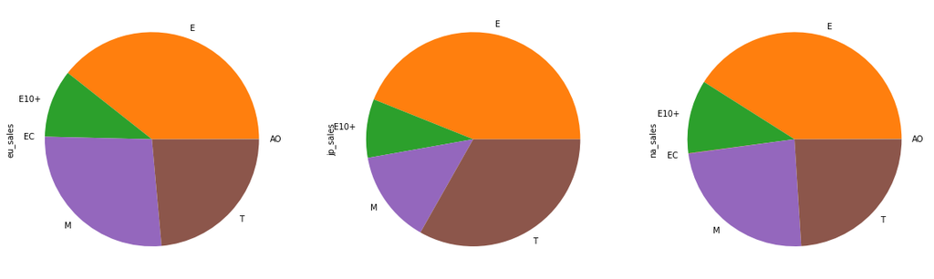

```python
df_esrb_region.plot.pie(subplots=True, figsize=(20, 10),legend = False, fontsize = 10);
```

Более всего продается игр с рейтингом Е - "для всех", затем следуют игры для подростков, затем для взрослых и для детей старше 10 лет.

Не думаю, что категория определяет продажи. Скорее при прогнозировании продаж, игру разрабатывают под определенную категорию.

Но, следует отметить, что покупатели изучают категории и в своих предпочтениях ориетируются на условно "безопасные" игры.

Если рассматривать регионы продаж, то следует отметить, что в Европе и Америке продается значительно больше игр для взрослых чем в Японии.

В то время, как в Японии продается больше игр для подростков, по сравнению с Европой и Америкой.

```python
df['rating'].value_counts()
```

```
E       3923
T       2905
M       1536
E10+    1393
EC         8
AO         1
Name: rating, dtype: int64
```

```python
df['rating'].isna().sum()
```

```
6676
```

```python
df['rating'] = df['rating'].fillna(0)
df['rating'].value_counts()
```

```
0       6676
E       3923
T       2905
M       1536
E10+    1393
EC         8
AO         1
Name: rating, dtype: int64
```

```python
df_esrb_region = df.pivot_table(index='rating', values = ['na_sales','eu_sales','jp_sales'],
                                 aggfunc = 'sum')

df_esrb_region = df_esrb_region.query('eu_sales > 2')
df_esrb_region
```

| rating | eu_sales | jp_sales | na_sales |
| --- | --- | --- | --- |
| 0 | 609.65 | 836.74 | 1225.84 |
| E | 704.13 | 199.42 | 1276.80 |
| E10+ | 183.35 | 40.20 | 345.50 |
| M | 480.00 | 63.58 | 742.89 |
| T | 421.79 | 150.70 | 747.60 |

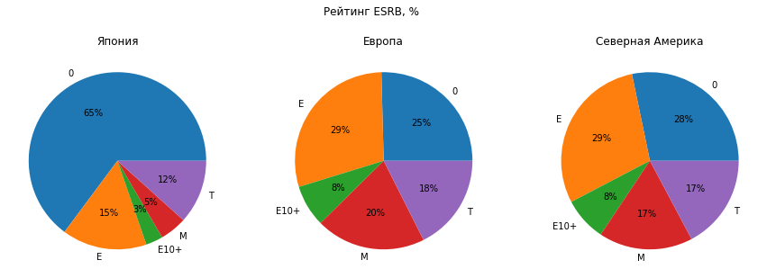

```python
fig, axs = plt.subplots(nrows=1 , ncols= 3,figsize=(15,5))
fig. suptitle('Рейтинг ESRB, %');

axs[0].pie(df_esrb_region['jp_sales'],autopct='%1.0f%%',labels = df_esrb_region['jp_sales'].index);
axs[0].set_title('Япония')


axs[1].pie(df_esrb_region['eu_sales'],autopct='%1.0f%%',labels = df_esrb_region['eu_sales'].index);
axs[1].set_title('Европа')

axs[2].pie(df_esrb_region['na_sales'],autopct='%1.0f%%',labels = df_esrb_region['na_sales'].index);
axs[2].set_title('Северная Америка')
plt.show()
```

Провели анализ рейтингов.

Можно посмотреть доли в актуальный период. Япония не участвовала в рейтинге, вероятно..

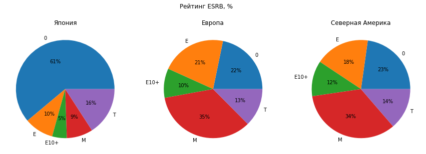

```python
df_esrb_region = df.query('year_of_release>2013').pivot_table(index='rating', values = ['na_sales','eu_sales','jp_sales'],
                                 aggfunc = 'sum')

df_esrb_region = df_esrb_region.query('eu_sales > 2')
fig, axs = plt.subplots(nrows=1 , ncols= 3,figsize=(15,5))
fig. suptitle('Рейтинг ESRB, %');

axs[0].pie(df_esrb_region['jp_sales'],autopct='%1.0f%%',labels = df_esrb_region['jp_sales'].index);
axs[0].set_title('Япония')


axs[1].pie(df_esrb_region['eu_sales'],autopct='%1.0f%%',labels = df_esrb_region['eu_sales'].index);
axs[1].set_title('Европа')

axs[2].pie(df_esrb_region['na_sales'],autopct='%1.0f%%',labels = df_esrb_region['na_sales'].index);
axs[2].set_title('Северная Америка')
plt.show()
```

Принципиально ситуация не улучшилась.

Поэтому делаем вывод, что в Японии менее 40 % игр получают рейтинг. Из тех игр, которые обладают рейтингом, больше всего игр категории "для тинейджеров"

В Европе и Северной Америке чуть более 20 % игр не получали рейтинг ESRB. Европейци и американцы больше всего приобретают игр с рейтингом "для взрослых".

### Вывод:

Был проанализирован портрет пользователя по регионам Япония, Северная Америка и Европа.

Можно отметить, что поведение покупателя в Европе и Северной Америке близки. Япония достаточно существенно отличается от этих регионов.

Анали проводился по платформам, жанрам и рейтингам.

Среди платформ в Японии лидирует 3DS с долей 48%, затем PS4 с долей 16%.

В Европе PS4 занимает 48%, XOne 17%

В Северной Америке так жи лидером является PS4 с долей 35%, второе место у XOne 29%.

Жанровые предпочтения пользователей выглядят следующим образом:

В Европе и Северной Америки на первом месте игры в жанре Action с долей 20%, затем Sports 15% и Shooter 13%. Есть различие в том что, американцы отдают предпочтение играм в жанре Platform 10%, а европейцы Racing с долей 10%.

В Японии пользователи предпочитают ролевые игры. Но в то же время, японцы так же как американцы любят игры в жанре Platform 10%.

Относительно рейтинга можно сказать, что

Япония имеет игры с рейтингом в небольшом количестве, около 40%. Среди этих игр, большая чать помечена рейтингом "для тинейджеров" 16% и "для всех" 10%.

В Европе и Северной Америке чуть более 20 % игр не получали рейтинг ESRB. Европейци и американцы больше всего приобретают игр с рейтингом "для взрослых" 35%.

## Гипотезы

### Пользовательские рейтинги платформ

  пороговое значение alpha зададим равное 5%

```python
df_box_1 = df_box[df_box['platform']=='ps4']
df_box_2 = df_box[df_box['platform']=='xone']
df_box_1 = df_box_1.dropna(subset=['user_score'])
df_box_2 = df_box_2.dropna(subset=['user_score'])
```

```python
alpha = 0.05
print(np.var(df_box[df_box['platform']=='ps4']['user_score']),
      np.var(df_box[df_box['platform']=='xone']['user_score']))

results_duration = st.ttest_ind(df_box_1['user_score'],df_box_2['user_score'])

print('p-значение:', results_duration.pvalue)

if results_duration.pvalue < alpha:
    print('Отвергаем нулевую гипотезу.')
else:
    print('Не можем отвергнуть нулевую гипотезу.')
```

```
2.121796544989326 1.8965188383045526
p-значение: 0.10169342039498884
Не можем отвергнуть нулевую гипотезу.
```

```python
df_box_score = df_box.pivot_table(index=['platform'],values = 'user_score', aggfunc ='mean')
df_box_score
```

| platform | user_score |
| --- | --- |
| ps4 | 6.748249 |
| xone | 6.521429 |

Не можем отвергнуть нулевую гипотезу о равенстве пользовательских рейтингов.

Если бы мы задавали пороговое значение более 11%, то можно было бы отвергнуть нулевую гипотезу и сказать что средние пользовательские рейтинги не равны. Но 11% это очень высокий параметр. Принимать его не стоит в данном случае.

### Пользовательские рейтинги жанров

• Средние пользовательские рейтинги жанров Action и Sports разные

- Н0 средние пользовательские рейтинги жанров Action и Sports равны
- Н1 средние пользовательские рейтинги жанров Action и Sports не равны

  рассмотрим двухстороннию гипотезу

  пороговое значение alpha зададим равное 5%

```python
df_genre_st = df.dropna(subset=['user_score'])
df_genre_st_1 = df_genre_st[df_genre_st['genre'] == 'Action']
df_genre_st_2 = df_genre_st[df_genre_st['genre'] == 'Sports']
```

```python
alpha = 0.05
print(np.var(df_genre_st[df_genre_st['genre'] == 'Action']['user_score']),
             np.var(df_genre_st[df_genre_st['genre'] == 'Sports']['user_score']))

results_duration = st.ttest_ind(df_genre_st_1['user_score'],df_genre_st_2['user_score'])

print('p-значение:', results_duration.pvalue)

if results_duration.pvalue < alpha:
    print('Отвергаем нулевую гипотезу.')
else:
    print('Не можем отвергнуть нулевую гипотезу.')
```

```
2.0263648741821716 2.621103395061729
p-значение: 0.06833686503882228
Не можем отвергнуть нулевую гипотезу.
```

```python
print(df_genre_st_1['user_score'].mean())
print(df_genre_st_2['user_score'].mean())
```

```
7.058129175946549
6.9527777777777775
```

Нулевую гипотезу не можем отвергнуть. Если возьмем 7% пороговое значение, то уже будем отвергать.

Или возьмем отдносторонний тест, тоже будем отвергать нулевую гипотезу.

Рассмотрим следующие гипотезы:

- Н0 средние пользовательские рейтинги жанров Action и Sports равны
- Н1 средние пользовательские рейтинги жанра Action больше, чем средние пользовательские рейтинги Sports

```python
alpha = 0.05
print(np.var(df_genre_st[df_genre_st['genre'] == 'Action']['user_score']),
             np.var(df_genre_st[df_genre_st['genre'] == 'Sports']['user_score']))

results_duration = st.ttest_ind(df_genre_st_1['user_score'],df_genre_st_2['user_score'],alternative = 'greater')

print('p-значение:', results_duration.pvalue)

if results_duration.pvalue < alpha:
    print('Отвергаем нулевую гипотезу.')
else:
    print('Не можем отвергнуть нулевую гипотезу.')
```

```
2.0263648741821716 2.621103395061729
p-значение: 0.03416843251941114
Отвергаем нулевую гипотезу.
```

```python
alpha = 0.05
print(np.var(df_genre_st[df_genre_st['genre'] == 'Action']['user_score']),
             np.var(df_genre_st[df_genre_st['genre'] == 'Sports']['user_score']))

results_duration = st.ttest_ind(df_genre_st_2['user_score'], df_genre_st_1['user_score'], alternative = 'greater')

print('p-значение:', results_duration.pvalue)

if results_duration.pvalue < alpha:
    print('Отвергаем нулевую гипотезу.')
else:
    print('Не можем отвергнуть нулевую гипотезу.')
```

```
2.0263648741821716 2.621103395061729
p-значение: 0.9658315674805888
Не можем отвергнуть нулевую гипотезу.
```

```python
alpha = 0.035
print(np.var(df_genre_st[df_genre_st['genre'] == 'Action']['user_score']),
             np.var(df_genre_st[df_genre_st['genre'] == 'Sports']['user_score']))

results_duration = st.ttest_ind(df_genre_st_2['user_score'], df_genre_st_1['user_score'], alternative = 'less')

print('p-значение:', results_duration.pvalue)

if results_duration.pvalue < alpha:
    print('Отвергаем нулевую гипотезу.')
else:
    print('Не можем отвергнуть нулевую гипотезу.')
```

```
2.0263648741821716 2.621103395061729
p-значение: 0.03416843251941114
Отвергаем нулевую гипотезу.
```

## Вывод:

[output not shown]

- выявить определяющие успешность игры закономерности
  - игры должны выпускаться на актуальных платформах. Для прогноза успеха игры в 2017 годы будут важны следующие платформы: WIIU, x360, WII, PS4, XOne и PC
  - платформы имеют распределение по регионам, перечислены в исследовании.
  - высокие отзовы критиков положительны для успешности игры
  - анализ по жанрам и регионам, показал что у покупателей есть предпочтения, их необходимо учитывать при выборе игр для продажи в магазине или проведении рекламной компании
- сделать ставку на потенциально популярный продукт
  - учитывая проведенный анализ, можно выделить следующие игры

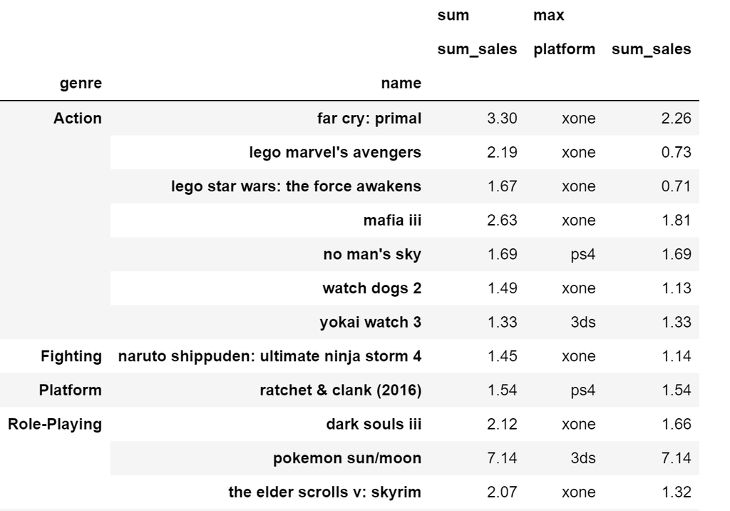

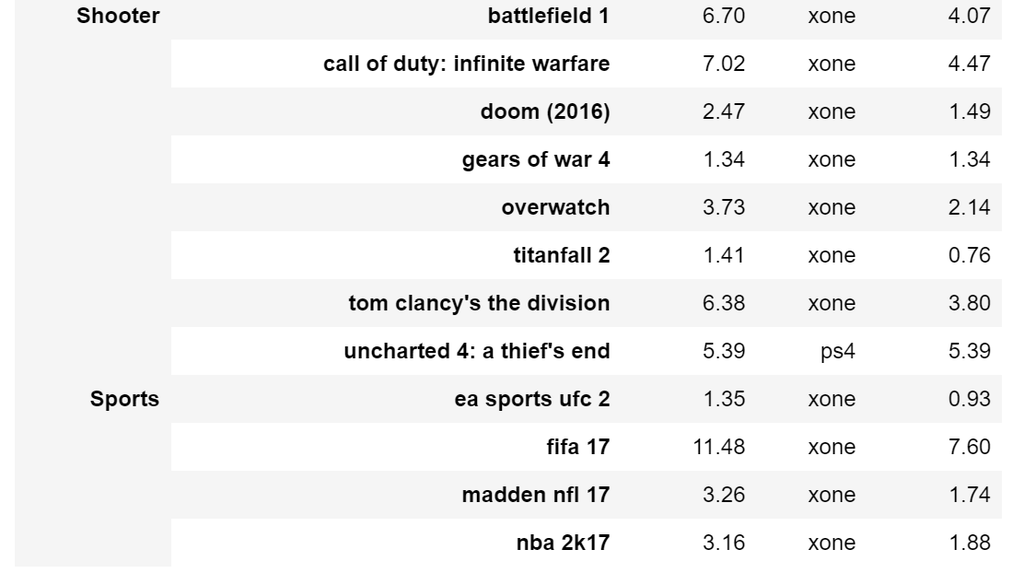

  - спланировать рекламные компании
    - список игр для рекламной компании представлен. Прошу обратить внимание на различие в регионах.